# Hypothesis Testing with R

目录

# Hypothesis Testing with R

## T-test for population means

### Statistical Inference

- Statistical inference is the process of drawing conclusions about a population on the basis of measurements or observations made on a sample.
- The conclusion of a statistical inference is a statistical proposition(统计命题).
- Some common forms of statistical proposition:
  - **point estimate(点估计)**, a particular value that best approximates some parameter of interest;
  - **interval estimate(区间估计)**, a confidence interval;
  - **rejection of a hypothesis(拒绝某假设检验)**

### Point Estimate

Common ways to find the point estimate:

- **Moment estiamtor**: The method of moments was introduced by K. Pearson and P. Chebyshev in 1887, and it is one of the oldest methods of estimation. This method is based on *law of large numbers*, which uses all the known facts about a population and apply those facts to a sample of the population by deriving equations that relate the population moments to the unknown parameters. We can then solve with the sample mean of the population moments. However, due to the simplicity, *this method is not always accurate* and can be biased easily. Let $(X_1, X_2,…X_n)$ be a random sample from a population having p.d.f. (or p.m.f) $f(x,θ), θ = (θ_1, θ_2, …, θ_k)$. The objective is to estimate the parameters $θ_1, θ_2, ..., θ_k$. Further, let the first k population moments about zero exist as explicit function of θ, i.e. $μ_r = μ_r(θ_1, θ_2,…, θ_k)$, r = 1, 2, …, k. In the method of moments, we equate k sample moments with the corresponding population moments. Generally, the first k moments are taken because the errors due to sampling increase with the order of the moment. Thus, we get k equations $μ_r(θ_1, θ_2,…, θ_k) = m_r$, r = 1, 2, …, k. Solving these equations we get the method of moment estimators (or estimates) as$ m_r = {ΣX_i^r\over n}$. See also generalized method of moments.
- **MLE**:The method of maximum likelihood, due to R.A. Fisher, is the most important general method of estimation. This estimator method attempts to acquire unknown parameters that maximize the likelihood function. It uses a known model (ex. the normal distribution) and uses the values of parameters in the model that maximize a likelihood function to find the most suitable match for the data. Let $X = (X_1, X_2, ... ,X_n)$ denote a random sample with joint p.d.f or p.m.f. $f(x, θ)$ ($θ$ may be a vector). The function $f(x, θ)$, considered as a function of $θ$, is called the likelihood function. In this case, it is denoted by L(θ). The principle of maximum likelihood consists of choosing an estimate within the admissible range of θ, that maximizes the likelihood. This estimator is called the maximum likelihood estimate (MLE) of θ. In order to obtain the MLE of θ, we use the equation ${{\rm d logL}(θ)\over{\rm d}θ_i}=0, i = 1, 2, …, k. $If θ is a vector, then partial derivatives are considered to get the likelihood equations.

### Interval Estimate

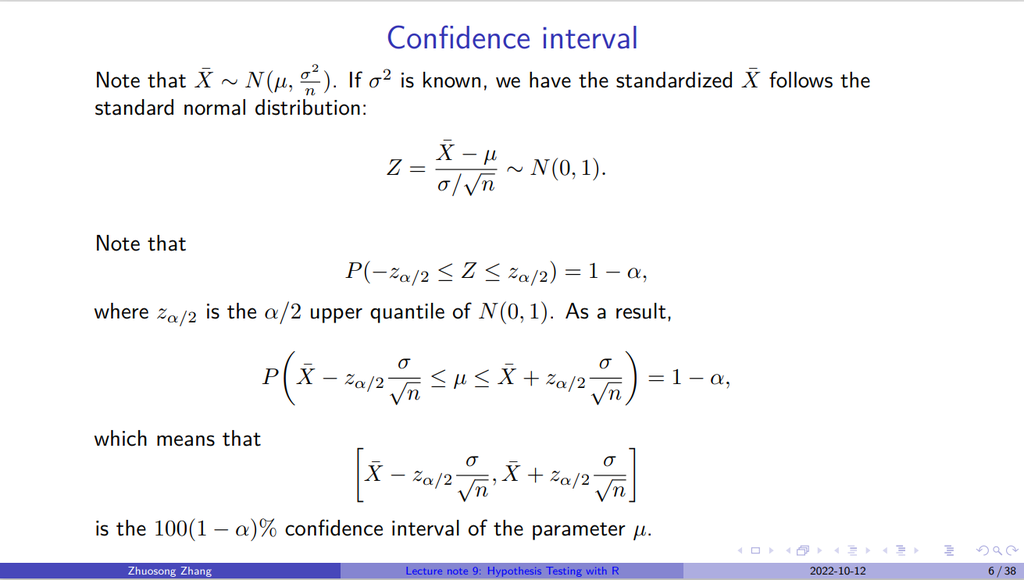

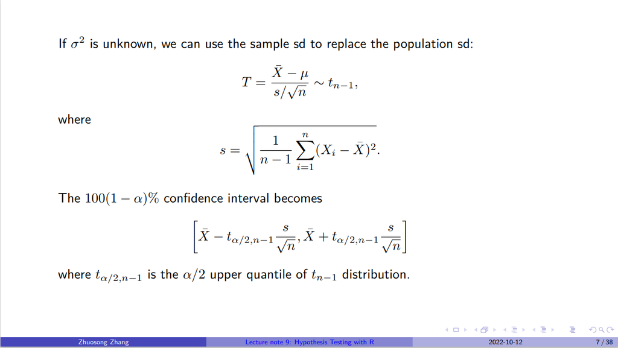

Write a function to calculate the confidence interval:

```r
# import the data set
library(tidyr)
library(palmerpenguins)
penguins <- drop_na(penguins)
x <- penguins$body_mass_g
xbar <- mean(x)
s <- sd(x)
n <- length(x)
alpha <- 0.05
t.quantile <- qt(alpha/2, df = n - 1, lower = FALSE)
ci.lower <- xbar - t.quantile * s / sqrt(n)
ci.upper <- xbar + t.quantile * s / sqrt(n)
c(ci.lower, ci.upper)
```

1. 4120.25613262312

2. 4293.857981491

### Hypothesis testing

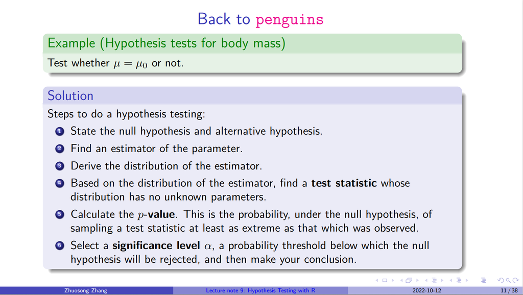

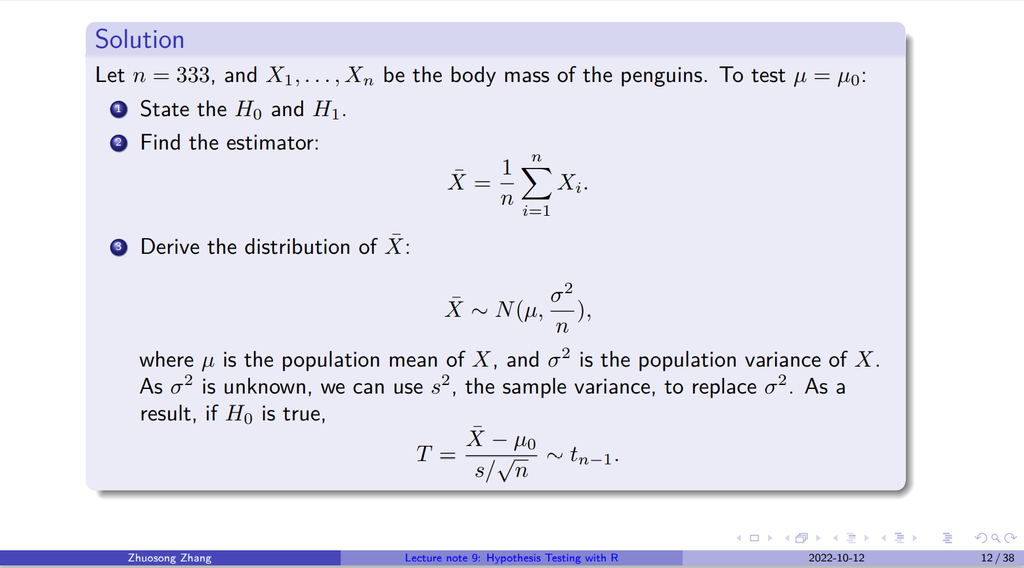

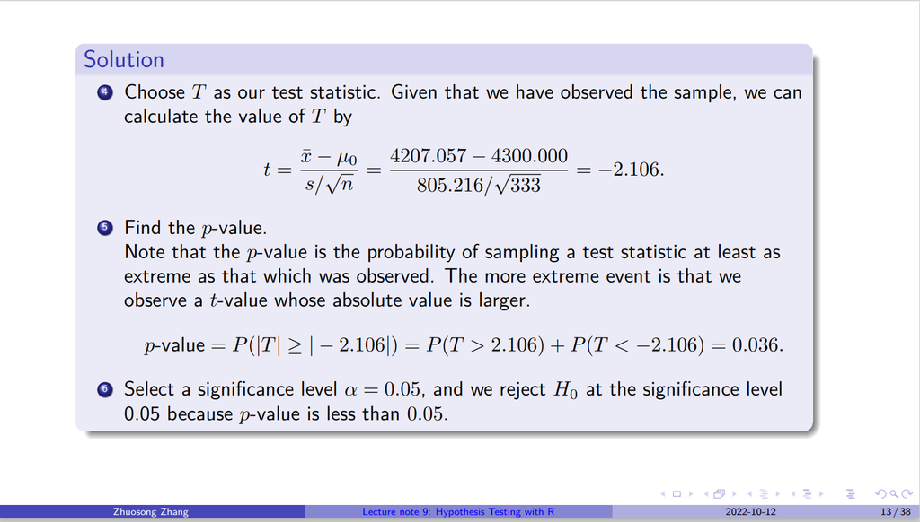

**Remarks:**

- There are two kinds of alternative hypothesis, *two-sides* and *one-sides*. The main difference is the p-value.
- For the *one-side* case, we don't need to calculate the absolute probability. For example, if we want to test whether µ < µ0 or not, the alternative hypothesis becomes $$H_1: \mu < \mu_0. $$ As a result, we only reject $H_0$ if your observation of $T$ is too small. The p-value becomes $$p-value=P(T<t)=P(T<-2.106)=0.018.$$

Write a function to calculate the p-value:

```r
# import the data set
library(palmerpenguins)
penguins <- drop_na(penguins)
x.bar <- 4207.057
mu0 <- 4300
s <- 805.216
n <- 333
t <- (x.bar-mu0)/(s/n^0.5)
t
2*pt(- abs(t),df=n-1)
```

-2.10632997054272

0.0359259032427813

**Rejection rejion:**

The steps 5 and 6 can be replaced by the rejection region method.

- Given a significance level $α$ and based on the distribution of the test statistic, we can calculate the threshold of the t-value.
- For example, for the two-tailed hypothesis, we should reject the null hypothesis if the t-value is too small or too large. Given that $α = 0.05$,$$P(|T|>t_{\alpha /2,n-1})=\alpha,$$where $t_{\alpha /2,n-1}$ is the $\alpha/2$ upper-quantile of the $t_{n-1}$ distribution, which can be calculated by

```r
qt(0.05/2,df=n-1,lower=FALSE)
```

1.96713505671906

- Note that our observation is -2.106, which falls into the rejection region, and then we reject the null hypothesis at the significance level 0.05.

**Build-in function: t.test**

```r
t.test(x,...)

# Default S3 method:
t.test(x,
      alternative = c("two-sided","less","greater"),
      mu = 0,
      conf.level = 0.95, ...)
```

```r
with(penguins, t.test(body_mass_g, mu = 4300))
```

```
	One Sample t-test

data:  body_mass_g
t = -2.1063, df = 332, p-value = 0.03593
alternative hypothesis: true mean is not equal to 4300
95 percent confidence interval:
 4120.256 4293.858
sample estimates:
mean of x
 4207.057
```

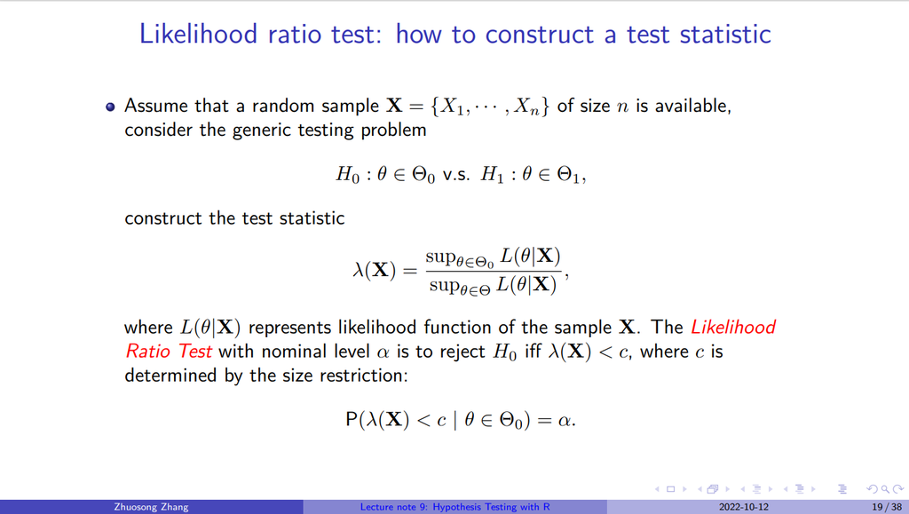

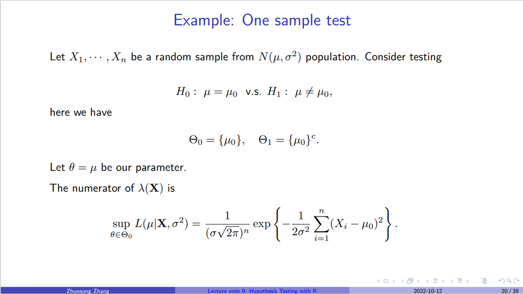

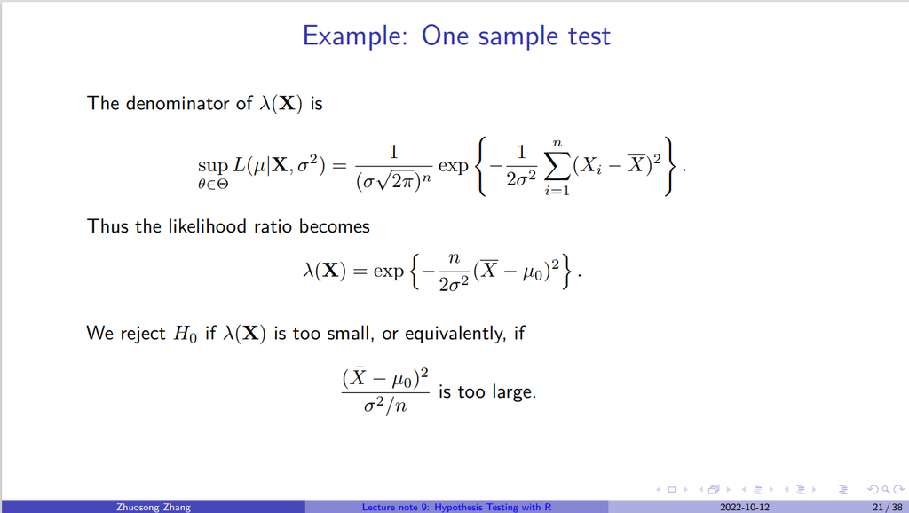

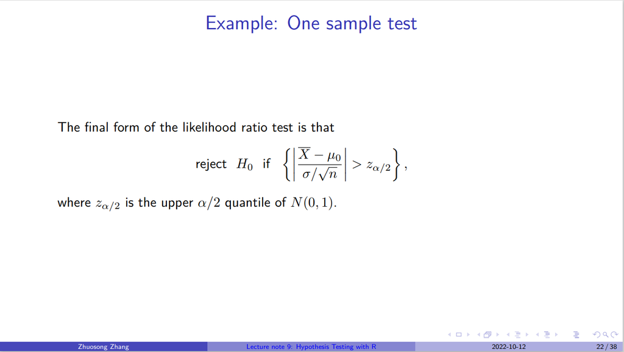

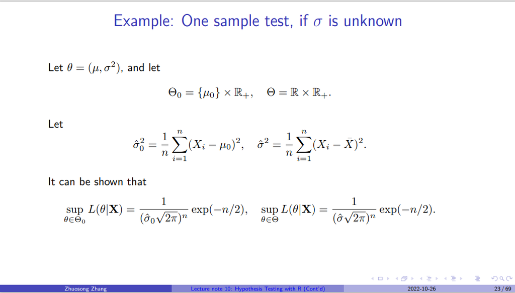

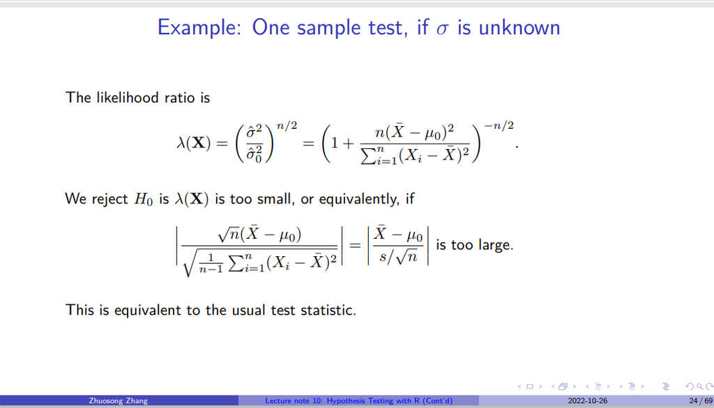

We can use the boxplot to see whether the population means are equal:

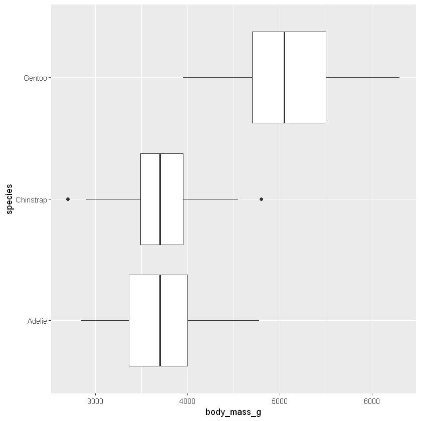

```r
library(tidyr)
library(tidyverse)
penguins %>%
  ggplot(mapping = aes(x = body_mass_g, y = species))+
  geom_boxplot()
```

**Two-sample t test:**

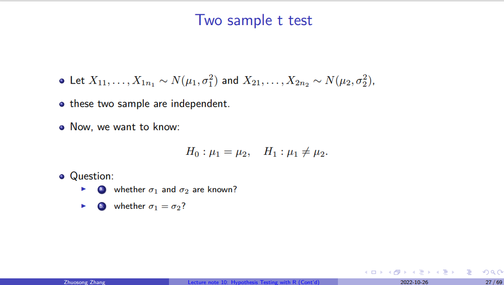

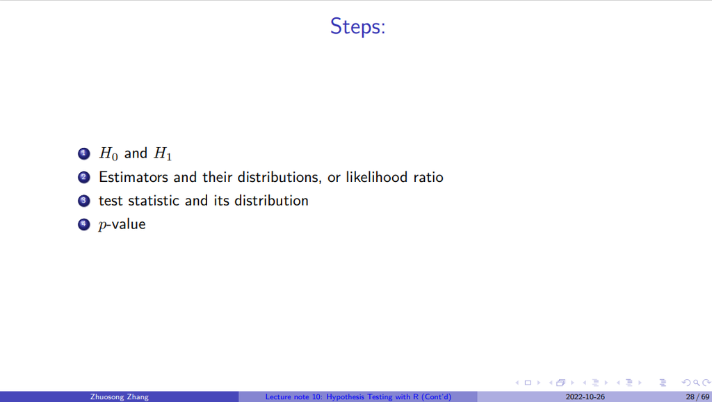

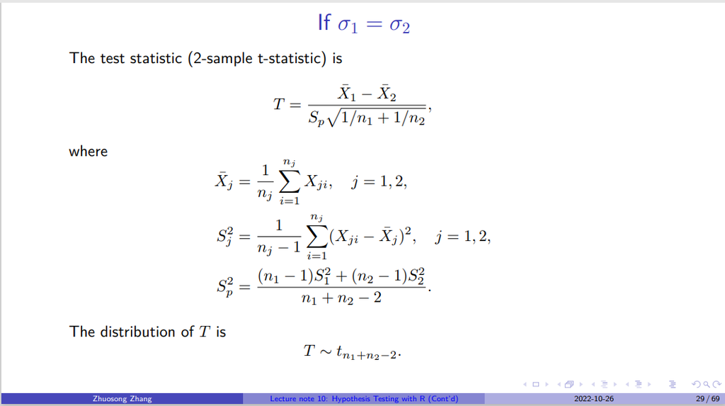

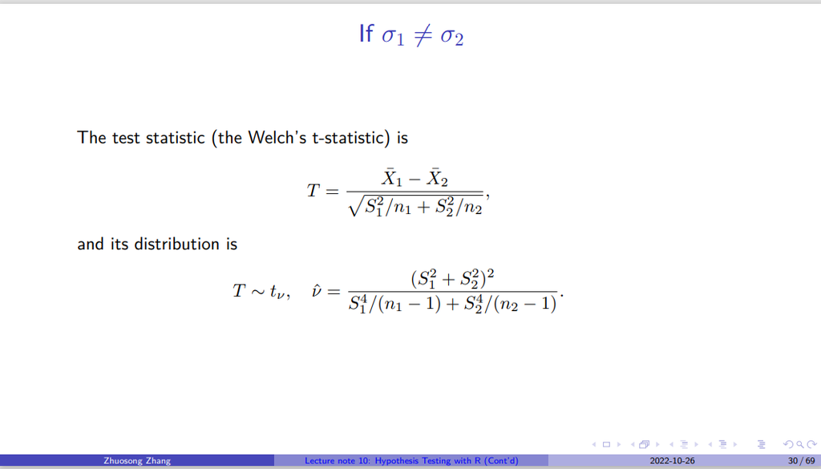

### Paired data

```r
library(dplyr)
data(UScrime)
```

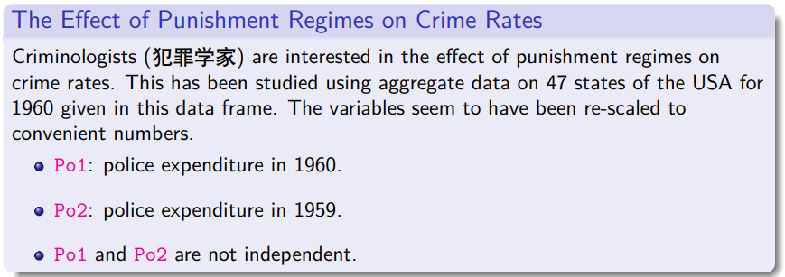

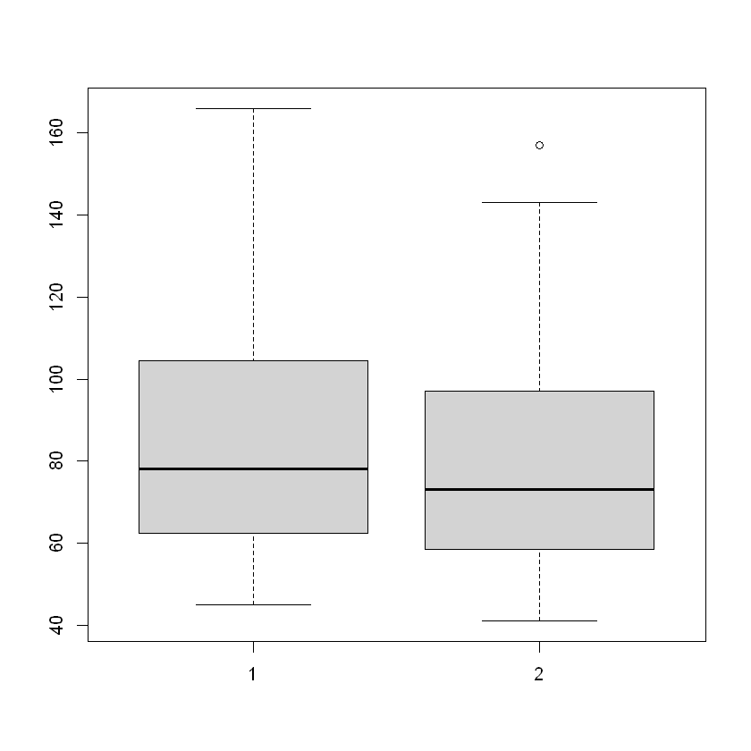

```r
with(UScrime,boxplot(Po1,Po2))
```

**Properties of paired data:**

- sample sizes are equal
- samples are not independent

**Test statistic:**

Let $$D_i = X_{1i}-X_{2i}.$$ The problem becomes to test whether $$\mu_D=0.$$This is a one-sample test.

#### Several ways to test normality

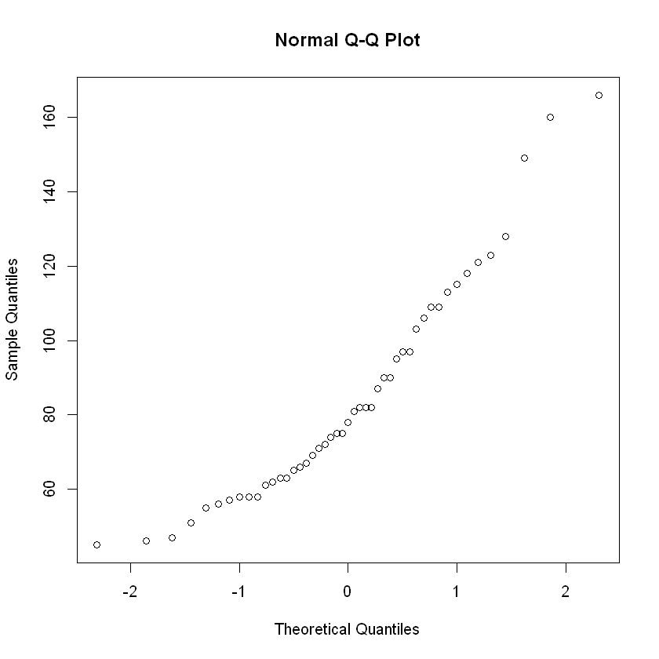

```r
qqnorm(UScrime$Po1)
```

- Sapiro-Wilk test: shape.test()
- Anderson-Darling test: nortest::ad.test()
- Kolmogorov-Smirnov test: ks.test()

```r
with(UScrime, shapiro.test(Po1))
```

```
	Shapiro-Wilk normality test

data:  Po1
W = 0.92307, p-value = 0.004281
```

## Nonparametric tests with R

### Wilcoxon Signed-Rank Test

- The Wilcoxon signed-rank test was proposed in Wilcoxon (1945).
- It can be used in both one- and two-sample case.

### One sample case

- Let $ Y_1, · · · , Y_n$ be i.i.d. random variables with the common absolutely continuous distribution $F$.
- $F$ distribution is symmetric.
- $µ$: median of $F$.
- Suppose that we want to test $$H_0:\mu = 0,~~{\rm v.s.}~~H_1:\mu \neq 0.$$

**Rank of data**

- The data can be ordered from smallest to largest.
- For example, if we observed $$x_1=3,~x_2=5,~x_3=9,~x_4=10,~x_5=4$$
- Then the ordered data is $$x_{(1)}=x_1=3,~x_{(2)}=x_5=4,~x_{(3)}=x_2=5,~x_{(4)}=x_3=9,~x_{(5)}=x_4=10$$
- We have $$r_1=1,~r_2=3,~r_3=4,~r_4=5,~r_5=2.$$

```r
x <- c(3,5,9,10,4)
rank(x)
```

1. 1

2. 3

3. 4

4. 5

5. 2

**Wilcoxon’s statistic**

- Let $R_1,...,R_n$ be the rank of $$|Y_1 − \mu_0|, · · · , |Y_n − \mu_0|.$$
- Define $$\Psi_i=\left\{ \begin{aligned} 0~~~~ & {\rm if}~ Y_i-\mu_0<0, \\ 1~~~~ & {\rm if}~ Y_i-\mu_0 \geq 0. \\ \end{aligned} \right. $$
- The Wilcoxon's signed rank statistic is defined by$$W = \sum_{i=1}^n R_i\Psi_i.$$

```r
y <- c(3,5,9,10,4)
mu0 <- 5
(y.cen.abs <- abs(y-mu0))
(r <- rank(y.cen.abs))
(psi <- (y > mu0))
(w <- sum(r*psi))
```

1. 2

2. 0

3. 4

4. 5

5. 1

1. 3

2. 1

3. 4

4. 5

5. 2

1. FALSE

2. FALSE

3. TRUE

4. TRUE

5. FALSE

9

**A large sample Wilcoxon signed rank test**

- To test $H_0 : µ = µ_0$ and $H_1 : µ > µ_0$ at the $α$ level of significance, we reject $H_0$ if $z > z_α$.
- To test $H_0 : µ = µ_0$ and $H_1 : µ < µ_0$ at the $α$ level of significance, we reject $H_0$ if $z < z_α$.
- To test $H_0 : µ = µ_0$ and $H_1 : µ \neq µ_0$ at the $α$ level of significance, we reject $H_0$ if $z < z_α$ or $z > z_\alpha$.
- The $p$-value can be calculated.

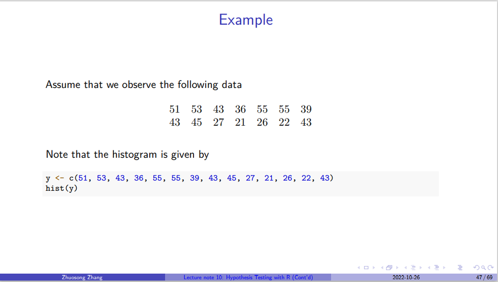

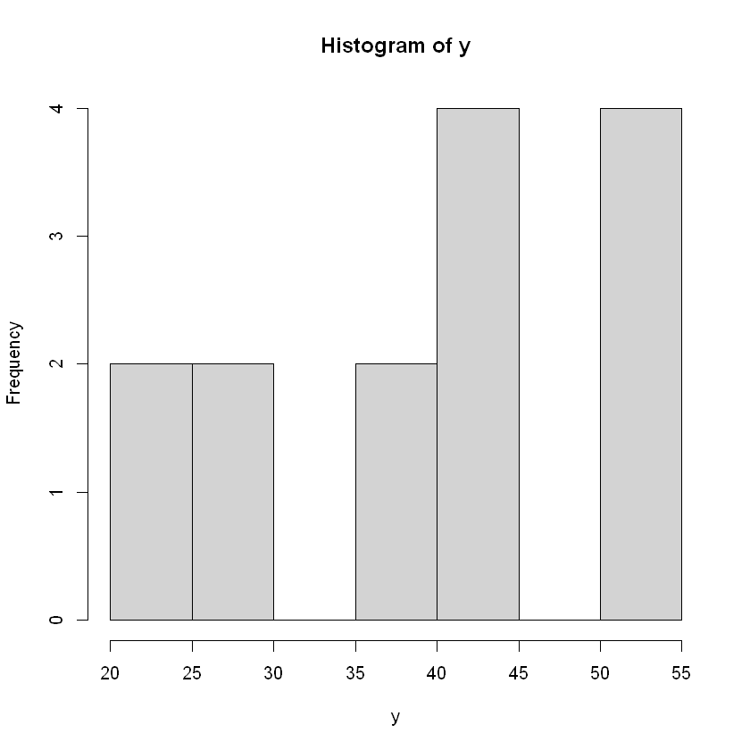

```r
y <- c(51, 53, 43, 36, 55, 55, 39, 43, 45, 27, 21, 26, 22, 43)
hist(y)
```

We want to test $$H_0 : µ = 28~~~ {\rm v.s.}~~~H_1 : µ > 28. $$

```r
r <- rank(abs(y-28))
psi <- (y>28)
w <- sum(r * psi)
n <- length(y)
mean_w <- n * (n + 1) / 4
sd_w <- sqrt(n * (n + 1) * (2 * n + 1) / 24)
(z <- (w - mean_w)/sd_w)
```

2.66800048744096

```r
(z_crit <- qnorm(0.95))
```

1.64485362695147

```r
(p_value <- pnorm(z,lower.tail=FALSE))
```

0.0038152073696228

```r
wilcox.test(y,mu=28,alternative = "greater",exact=FALSE)$p.value
```

0.00414694903958007

```r
wilcox.test(y,mu=28,alternative = "greater",exact=FALSE,correct=FALSE)$p.value ## correct 代表连续修正，将连续分布用于估计离散分布
```

0.00377799105508599

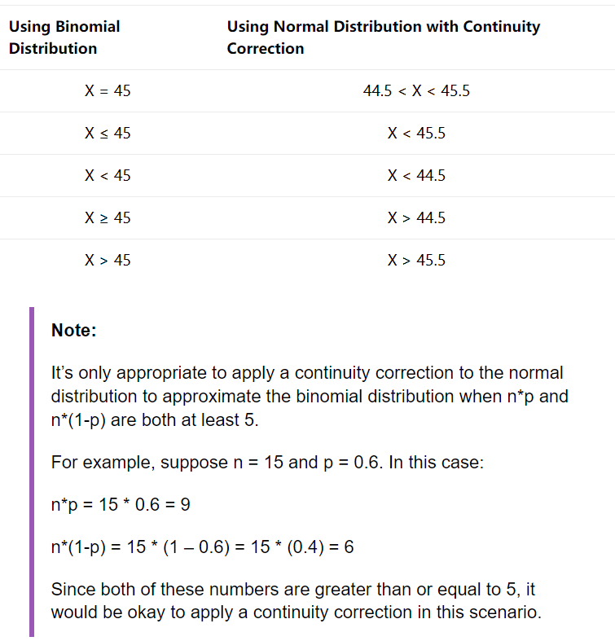

### Testing Paired data

- A Wilcoxon signed rank test can also be used on paired data to test $H_0:\mu_D=0,$ where $\mu_D=\mu_X-\mu_Y.$
- Suppose we have a random sample of size $n$, $(x_i,y_i)$, $1 ≤ i ≤ n$, and let $$d_i=x_i-y_i.$$
- Let $r_i$ be the rank of $|d_i|$ in the set $$|d_1|,...,|d_n|.$$
- Define $$\phi_i=I(x_i>y_i).$$
- Let $$w=\sum_{i=1}^n r_i\phi_i.$$

**Example**

Hamilton depression scale factor measurements in 9 patients with mixed anxiety and depression, taken at the first (x) and second (y) visit after initiation of a therapy (administration of a tranquilizer).

We want to test $$H_0 : \mu_X = \mu_Y ~~{\rm v.s.}~~ H_1 : \mu_X > \mu_Y .$$

```r
x <- c(1.83, 0.50, 1.62, 2.48, 1.68, 1.88, 1.55, 3.06, 1.30)
y <- c(0.878, 0.647, 0.598, 2.05, 1.06, 1.29, 1.06, 3.14, 1.29)
wilcox.test(x,y,paired=TRUE, alternative = "greater")
```

```
	Wilcoxon signed rank exact test

data:  x and y
V = 40, p-value = 0.01953
alternative hypothesis: true location shift is greater than 0
```

### Testing two independent random samples

- Let $X_1,...,X_n$ and $Y_1,...,Y_m$ be two independent random samples of sizes $n$ and $m$ from $f_X$ and $f_Y$, respectively.
- For $1 ≤ i ≤ n + m$, let $R_i$ be the rank of the ith observation in the combined sample, and let $$\Psi_i=\left\{ \begin{aligned} 1~~~~ & {\rm if}~ {\rm the}~i~{\rm~th~observation~came~from~} f_X, \\ 0~~~~ & {\rm if}~ {\rm the}~i~{\rm~th~observation~came~from~} f_Y. \\ \end{aligned} \right.$$
- Define $$W=\sum_{i=1}^{n+m}R_i\Psi_i.$$

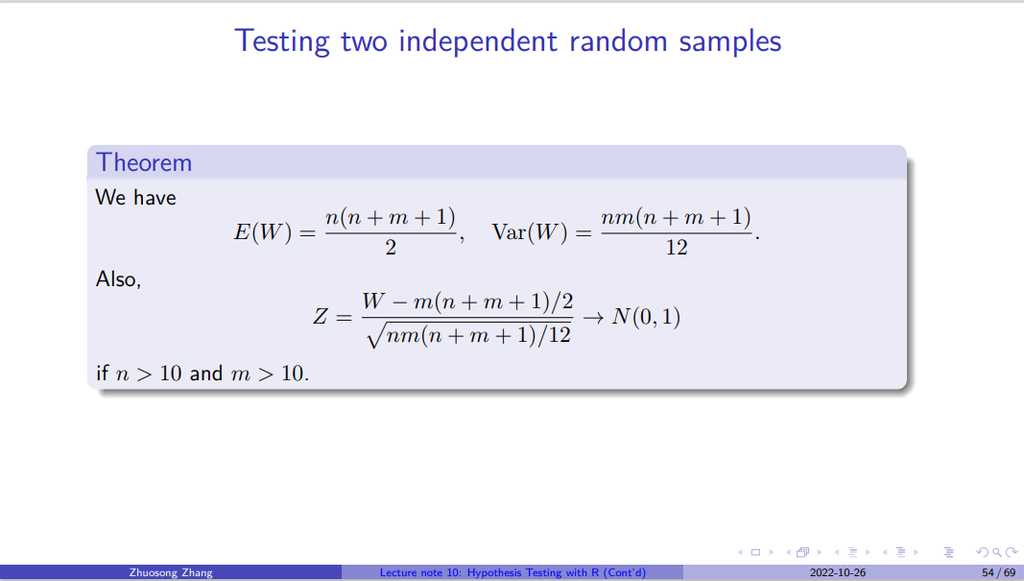

**Example**

Permeability constants of the human chorioamnion (a placental membrane) at term ($x$) and between 12 to 26 weeks gestational age ($y$). The alternative of interest is greater permeability of the human chorioamnion for the term pregnancy.

```r
x <- c(0.80, 0.83, 1.89, 1.04, 1.45, 1.38, 1.91, 1.64, 0.73, 1.46)
y <- c(1.15, 0.88, 0.90, 0.74, 1.21)
wilcox.test(x, y, alternative = "greater",exact = FALSE, correct = FALSE)
```

```
	Wilcoxon rank sum test

data:  x and y
W = 35, p-value = 0.1103
alternative hypothesis: true location shift is greater than 0
```

## Monte Carlo Methods for hypothesis tests

### Type-I error and Type-II error

Suppose that we wish to test a hypothesis for $θ$: $$H_0:\theta \in \Theta_0~~~{\rm v.s.}~~~H_1:\theta \in \Theta_1,$$ where $\Theta_0$ and $\Theta_1$ partition the parameter space $\Theta$.

- **Type-I error** and **Type-II error**
- **Type-I error** is that we reject $H_{0}$ given that $H_0$ is true.
- **Type-II error** is that we *fail* to reject $H_0$ given that $H_0$ is not true.
- **Power of a test** is that we reject $H_0$ given that $H_0$ is not true.
- In the one-sample t-test, we assume that $X_1,...,X_n \sim N(\mu,\sigma^2)$;
- Consider $$H_0:\mu = \mu_0~~~{\rm v.s.}~~~H_1:\mu > \mu_0,$$
- The rejection region is: $$\bar{x}\geq \mu_0 + t_{\alpha,n-1}\frac{s}{\sqrt{n}}.$$
- Then what is the type-I error?
- Type-I error equals to $\alpha$!

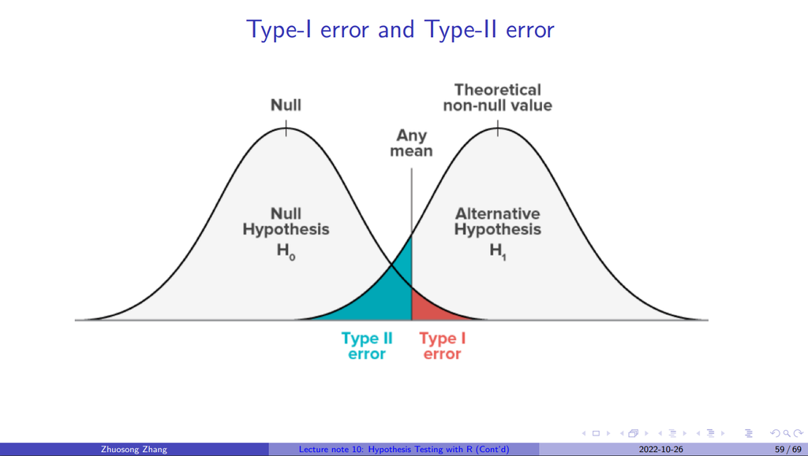

**Central limit theorem** If we don't know the distribution of $\{X_i\}_{i=1}^n$, then how do we construct the confidence interval?

- By the central limit theorem, we know that $$\frac{\bar{X}-\mu_0}{\sigma/\sqrt{n}}\implies N(0,1)$$
- By the law of large numbers $$s^2=\frac{1}{n-1}\sum_{i=1}{n}(X_i-\bar{X})^2\stackrel{P}{\longrightarrow}\sigma^2.$$
- Therefore, $$\frac{\bar{X}-\mu_0}{s/\sqrt{n}}=\frac{\bar{X}-\mu_0}{\sigma/\sqrt{n}}\times \frac{\sigma}{s}\implies N(0,1).$$
- Moreover, as $n\to \infty$, $$t_{\alpha,n-1}\to z_{\alpha},$$
- Hence, $$P(\frac{\bar{X}-\mu_0}{s/\sqrt{n}}\geq t_{\alpha,n-1})\to P(N(0,1)\geq z_{\alpha})=\alpha$$
- 意味着，当$n$趋向于无穷大的时候，仍可以按照原假设的t分布进行分析，即使用t的分位点进行P值运算等。
- 但实际上$n$并不能取到无穷大，那我们该如何计算该概率:$$P(\frac{\bar{X}-\mu_0}{s/\sqrt{n}}\geq t_{\alpha,n-1})$$ 这时可以使用Monte Carlo method来计算:

```r
n <- 20
alpha <- 0.05
mu0 <- 1
M <- 10000
t_value <- numeric(M)
set.seed(308)
for (j in 1:M){
x <- runif(n, mu0 - 1, mu0 + 1) #假设x属于均匀分布
t_value[j] <- (mean(x) - mu0)/(sd(x) / sqrt(n)) # 使用 t 检验
}
is.reject <- (t_value > qt(alpha, df = n - 1, lower = FALSE))
mean(is.reject)
```

0.0518

```r
n <- 20
alpha <- 0.05
mu0 <- 1
M <- 10000
p_value <- numeric(M)
set.seed(308)
for (j in 1:M){
x <- runif(n, mu0 - 1, mu0 + 1)
p_value[j] <- wilcox.test(x, mu = 1, alternative = "greater")$p.value   #使用 Wilcoxon 检验
}
is.reject <- (p_value < alpha)
mean(is.reject)
```

0.0498

### Power of a test

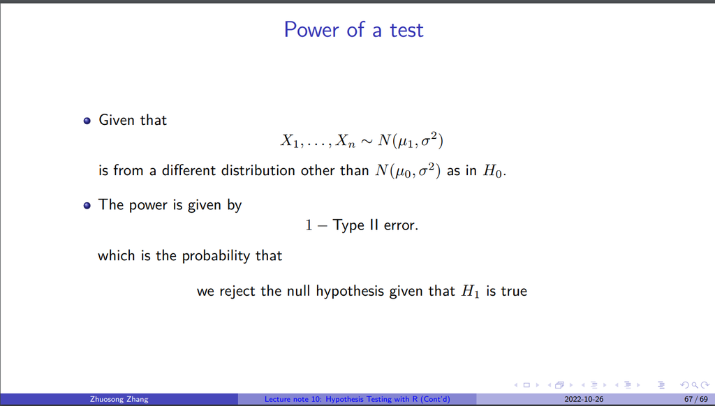

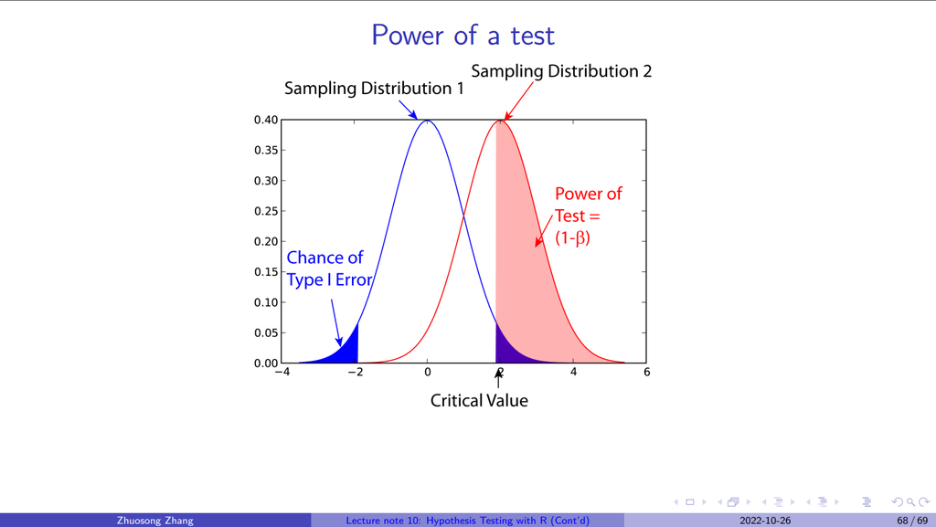